# Lab 2: Hand Gesture Recognition

This lab is based on an assignment developed by Prof. Lisa Zhang.

This lab will be completed in two parts. In Part A you will gain experience gathering your own data set (specifically images of hand gestures), and understand the challenges involved in the data cleaning process. In Part B you will train a convolutional neural network to make classifications on different hand gestures. By the end of the lab, you should be able to:

1. Generate and preprocess your own data
2. Load and split data for training, validation and testing
3. Train a Convolutional Neural Network
4. Apply transfer learning to improve your model

Note that for this lab we will not be providing you with any starter code. You should be able to take the code used in previous labs, tutorials and lectures and modify it accordingly to complete the tasks outlined below.

### What to submit

**Submission for Part A:**  
Submit a zip file containing your images. Three images each of American Sign Language gestures for letters A - I (total of 27 images). You will be required to clean the images before submitting them. Details are provided under Part A of the handout.

Individual image file names should follow the convention of student-number_Alphabet_file-number.jpg (e.g. 100343434_A_1.jpg).

**Submission for Part B:**  
Submit an HTML file containing all your code, outputs, and write-up from parts A and B. You can produce a HTML file directly from Google Colab. The Colab instructions are provided at the end of this document.

**Do not submit any other files produced by your code.**

Include a link to your colab file in your submission.

Please use Google Colab to complete this assignment. If you want to use Jupyter Notebook, please complete the assignment and upload your Jupyter Notebook file to Google Colab for submission.

## Colab Link

Include a link to your colab file here

Colab Link: https://drive.google.com/file/d/1IuYbZDrmhLctAdjEPt1sQfz8-I6XG8fQ/view?usp=sharing

# Part A. Data Collection [10 pt]

So far, we have worked with data sets that have been collected, cleaned, and curated by machine learning researchers and practitioners. Datasets like MNIST and CIFAR are often used as toy examples, both by students and by researchers testing new machine learning models.

In the real world, getting a clean data set is never that easy. More than half the work in applying machine learning is finding, gathering, cleaning, and formatting your data set.

The purpose of this lab is to help you gain experience gathering your own data set, and understand the challenges involved in the data cleaning process.

### American Sign Language

American Sign Language (ASL) is a complete, complex language that employs signs made by moving the hands combined with facial expressions and postures of the body. It is the primary language of many North Americans who are deaf and is one of several communication options used by people who are deaf or hard-of-hearing.

The hand gestures representing English alphabet are shown below. This lab focuses on classifying a subset of these hand gesture images using convolutional neural networks. Specifically, given an image of a hand showing one of the letters A-I, we want to detect which letter is being represented.

[figure not shown]

### Generating Data

We will produce the images required for this lab by ourselves. Each student will collect, clean and submit three images each of Americal Sign Language gestures for letters A - I (total of 27 images) Steps involved in data collection

1. Familiarize yourself with American Sign Language gestures for letters from A - I (9 letters).
2. Take three pictures at slightly different orientation for each letter gesture using your mobile phone.
   - Ensure adequate lighting while you are capturing the images.
   - Use a white wall as your background.
   - Use your right hand to create gestures (for consistency).
   - Keep your right hand fairly apart from your body and any other obstructions.
   - Avoid having shadows on parts of your hand.
3. Transfer the images to your laptop for cleaning.

### Cleaning Data

To simplify the machine learning the task, we will standardize the training images. We will make sure that all our images are of the same size (224 x 224 pixels RGB), and have the hand in the center of the cropped regions.

You may use the following applications to crop and resize your images:

**Mac**

- Use Preview: – Holding down CMD + Shift will keep a square aspect ratio while selecting the hand area. – Resize to 224x224 pixels.

**Windows 10**

- Use Photos app to edit and crop the image and keep the aspect ratio a square.
- Use Paint to resize the image to the final image size of 224x224 pixels.

**Linux**

- You can use GIMP, imagemagick, or other tools of your choosing. You may also use online tools such as http://picresize.com All the above steps are illustrative only. You need not follow these steps but following these will ensure that you produce a good quality dataset. You will be judged based on the quality of the images alone. Please do not edit your photos in any other way. You should not need to change the aspect ratio of your image. You also should not digitally remove the background or shadows—instead, take photos with a white background and minimal shadows.

### Accepted Images

Images will be accepted and graded based on the criteria below

1. The final image should be size 224x224 pixels (RGB).
2. The file format should be a .jpg file.
3. The hand should be approximately centered on the frame.
4. The hand should not be obscured or cut off.
5. The photos follows the ASL gestures posted earlier.
6. The photos were not edited in any other way (e.g. no electronic removal of shadows or background).

### Submission

Submit a zip file containing your images. There should be a total of 27 images (3 for each category)

1. Individual image file names should follow the convention of student-number_Alphabet_file-number.jpg (e.g. 100343434_A_1.jpg)
2. Zip all the images together and name it with the following convention: last-name_student-number.zip (e.g. last-name_100343434.zip).
3. Submit the zipped folder. We will be anonymizing and combining the images that everyone submits. We will announce when the combined data set will be available for download.

[figure not shown]

# Part B. Building a CNN [40 pt]

For this lab, we are not going to give you any starter code. You will be writing a convolutional neural network from scratch. You are welcome to use any code from previous labs, lectures and tutorials. You should also write your own code.

You may use the PyTorch documentation freely. You might also find online tutorials helpful. However, all code that you submit must be your own.

Make sure that your code is vectorized, and does not contain obvious inefficiencies (for example, unecessary for loops, or unnecessary calls to unsqueeze()). Ensure enough comments are included in the code so that your TA can understand what you are doing. It is your responsibility to show that you understand what you write.

**This is much more challenging and time-consuming than the previous labs.** Make sure that you give yourself plenty of time by starting early.

### Part 1. Data Loading and Splitting [5 pt]

Download the anonymized data provided on Quercus. Split the data into training, validation, and test sets.

Note: Data splitting is not as trivial in this lab. We want our test set to closely resemble the setting in which our model will be used. In particular, our test set should contain hands that are never seen in training!

Explain how you split the data, either by describing what you did, or by showing the code that you used. Justify your choice of splitting strategy. How many training, validation, and test images do you have?

For loading the data, you can use plt.imread, or any other method that you choose. You may find torchvision.datasets.ImageFolder helpful. (see https://pytorch.org/docs/master/torchvision/datasets.html#imagefolder )

```python
import numpy as np
import time
import torch
import torch.nn as nn
import torch.nn.functional as F
import torch.optim as optim
import torchvision
from torch.utils.data.sampler import SubsetRandomSampler
import torchvision.transforms as transforms
import torchvision.datasets
import matplotlib.pyplot as plt

use_cuda = True
```

```python
from google.colab import drive
drive.mount('/content/drive')
```

```python
def get_data_loader(data_path, batch_size = 64):
    torch.manual_seed(100)
    np.random.seed(100)

    # Transform all image size into 224x224, and into tensor
    transform = transforms.Compose(
            [transforms.Resize([224, 224]),
             transforms.ToTensor()])

    # Load data
    dataset = torchvision.datasets.ImageFolder(root = data_path, transform=transform)

    # Split the data using their indices
    # In order to obtain larger training set to prevent overfitting when there
    # is a large set of parameters, I split into 80% training, 10% validation
    # and 10% test sets. A small set of test set will sensitively assess how well the model is.
    indices = np.arange(len(dataset))
    np.random.shuffle(indices)
    split1 = int(len(indices) * 0.8) # training set split at 80%
    split2 = int(len(indices) * 0.9) # validation set split at 90%

    # split data into training, validation and test set
    train_sampler = SubsetRandomSampler(indices[:split1])
    train_loader = torch.utils.data.DataLoader(dataset, batch_size=batch_size,
                                               num_workers=1, sampler=train_sampler)

    val_sampler = SubsetRandomSampler(indices[split1:split2])
    val_loader = torch.utils.data.DataLoader(dataset, batch_size=batch_size,
                                              num_workers=1, sampler=val_sampler)

    test_sampler = SubsetRandomSampler(indices[split2:])
    test_loader = torch.utils.data.DataLoader(dataset, batch_size=batch_size,
                                             num_workers=1, sampler=test_sampler)

    return train_loader, val_loader, test_loader
```

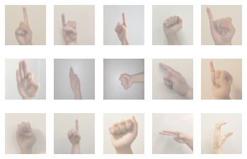

```python
master_path = "/content/drive/My Drive/MASc First Year/MIE1517/Lab2/Lab_3b_Gesture_Dataset"
train_loader, val_loader, test_loader = get_data_loader(data_path=master_path, batch_size = 1)

k = 0
for images, labels in train_loader:
    # since batch_size = 1, there is only 1 image in `images`
    image = images[0]
    # place the colour channel at the end, instead of at the beginning
    img = np.transpose(image, [1,2,0])
    # normalize pixel intensity values to [0, 1]
    img = img / 2 + 0.5
    plt.subplot(3, 5, k+1)
    plt.axis('off')
    plt.imshow(img)

    k += 1
    if k > 14:
        break
```

```python
# 80% of training set has 1944 images.
count = 0
for images, labels in train_loader:
    count += 1
print(count)
```

```
1944
```

```python
# 10% of validation set has 243 images.
count = 0
for images, labels in val_loader:
    count += 1
print(count)
```

```
243
```

```python
# 10% of test set has 244 images.
count = 0
for images, labels in test_loader:
    count += 1
print(count)
```

```
244
```

### Part 2. Model Building and Sanity Checking [10 pt]

### Part (a) Convolutional Network - 3 pt

Build a convolutional neural network model that takes the (224x224 RGB) image as input, and predicts the gesture letter. Your model should be a subclass of nn.Module. Explain your choice of neural network architecture: how many layers did you choose? What types of layers did you use? Were they fully-connected or convolutional? What about other decisions like pooling layers, activation functions, number of channels / hidden units?

```python
# This neural network consists of 6 layers, which are two convolutional layers
# each followed by a pooling layer (2 conv layers & 2 max pooling layers), and
# two fully connected linear layers.

# To prevent overfitting and large computation required, I try not to put too
# many layers to make the neural network deeper. Convolitional layers are used
# to detect small features everywhere from the images. Max pooling layers are
# very efficient to downsample the feature maps and extract the most important
# informations. The two fully connected layers are used to flatten and learn
# non-linear combinations of those high level features produced by conv and
# max pooling layers. Since the image size is big, using kernel size = 5 will be
# more effecient than 3. I set 5 as the number of output channels for both conv
# layers is to prevent too many parameters generated in each layer if I set a
# larger number of output channels. ReLu is used as the activation function,
# which is a half rectified function to deal with non-linearity from the conv
# layers and prevent the exponential growth in the computation for CNN.

class ASLClassifier1(nn.Module):
    def __init__(self):
        super(ASLClassifier1, self).__init__()
        self.name = 'ASLClassifier1'
        self.conv1 = nn.Conv2d(3, 5, 5) #in_channels, out_chanels, kernel_size
        self.pool = nn.MaxPool2d(2, 2) #kernel_size, stride
        self.conv2 = nn.Conv2d(5, 5, 5) #in_channels, out_chanels, kernel_size 4x4x10
        self.fc1 = nn.Linear(53*53*5, 32)
        self.fc2 = nn.Linear(32, 9)

    def forward(self, x):
        x = self.pool(F.relu(self.conv1(x)))
        x = self.pool(F.relu(self.conv2(x)))
        x = x.view(-1, 53*53*5)
        x = F.relu(self.fc1(x))
        x = self.fc2(x)
        return x
# 450779
```

```python
m1 = ASLClassifier1()
for param in m1.parameters():
    print(param.shape)
print(sum(p.numel() for p in m1.parameters()))
```

```
torch.Size([5, 3, 5, 5])
torch.Size([5])
torch.Size([5, 5, 5, 5])
torch.Size([5])
torch.Size([32, 14045])
torch.Size([32])
torch.Size([9, 32])
torch.Size([9])
450779
```

### Part (b) Training Code - 4 pt

Write code that trains your neural network given some training data. Your training code should make it easy to tweak the usual hyperparameters, like batch size, learning rate, and the model object itself. Make sure that you are checkpointing your models from time to time (the frequency is up to you). Explain your choice of loss function and optimizer.

```python
def get_model_name(name, batch_size, learning_rate, epoch):
    # checkpoint
    path = "model_{0}_bs{1}_lr{2}_epoch{3}".format(name, batch_size, learning_rate, epoch)
    return path
```

```python
def train(model, data_path = None, train_loader = None, val_loader = None,
          batch_size = 64, learning_rate=0.01, num_epochs=30):

    # Fixed PyTorch random seed for reproducible result
    torch.manual_seed(1000)

    if data_path is None:
        train_loader, val_loader = train_loader, val_loader
    else:
        train_loader, val_loader, test_loader = get_data_loader(data_path = data_path,
                                                            batch_size = batch_size)

    # Since this is still a multi-class classification problem, I use Cross
    # Entropy as the loss function. Adam is used for the optimizer since it
    # offers rapid convergence, which incorporates momentum, adaptive learning
    # rate and stochastic gradient descent.
    criterion = nn.CrossEntropyLoss()
    optimizer = optim.Adam(model.parameters(), lr=learning_rate)

    iters, losses, train_acc, val_acc = [], [], [], []

    # training
    # Start timing
    start_time = time.time()
    n = 0 # the number of iterations
    for epoch in range(num_epochs):
        for imgs, labels in iter(train_loader):

            #############################################
            #To Enable GPU Usage
            if use_cuda and torch.cuda.is_available():
              imgs = imgs.cuda()
              labels = labels.cuda()
            #############################################

            out = model(imgs)             # forward pass
            loss = criterion(out, labels) # compute the total loss
            loss.backward()               # backward pass (compute parameter updates)
            optimizer.step()              # make the updates for each parameter
            optimizer.zero_grad()         # a clean up step for PyTorch

            # save the current training information
            iters.append(n)
            losses.append(float(loss)/batch_size)
            train_acc.append(get_accuracy(model, train_loader)) # compute training accuracy
            val_acc.append(get_accuracy(model, val_loader))  # compute validation accuracy
            n += 1

        print(("Epoch {}: Train acc: {} |" + "Validation acc: {}").format(epoch, train_acc[-1], val_acc[-1]))

        model_path = get_model_name(model.name, batch_size, learning_rate, epoch)
        torch.save(model.state_dict(), model_path)

    # plotting
    plt.title("Training Curve")
    plt.plot(iters, losses, label="Train")
    plt.xlabel("Iterations")
    plt.ylabel("Loss")
    plt.show()

    plt.title("Training Curve")
    plt.plot(iters, train_acc, label="Train")
    plt.plot(iters, val_acc, label="Validation")
    plt.xlabel("Iterations")
    plt.ylabel("Training Accuracy")
    plt.legend(loc='best')
    plt.show()

    print("Final Training Accuracy: {}".format(train_acc[-1]))
    print("Final Validation Accuracy: {}".format(val_acc[-1]))

    end_time = time.time()
    elapsed_time = end_time - start_time
    print("Total time elapsed: {:.2f} seconds".format(elapsed_time))
```

```python
def get_accuracy(model, loader):
    correct = 0
    total = 0

    for imgs, labels in loader:
        #############################################
        #To Enable GPU Usage
        if use_cuda and torch.cuda.is_available():
          imgs = imgs.cuda()
          labels = labels.cuda()
        #############################################

        output = model(imgs)
        #select index with maximum prediction score
        pred = output.max(1, keepdim=True)[1]
        correct += pred.eq(labels.view_as(pred)).sum().item()
        total += imgs.shape[0]

    return correct / total
```

```
CUDA is available!  Training on GPU ...
Epoch 0: Train acc: 0.4104938271604938 |Validation acc: 0.37037037037037035
Epoch 1: Train acc: 0.6172839506172839 |Validation acc: 0.5679012345679012
Epoch 2: Train acc: 0.683641975308642 |Validation acc: 0.6460905349794238
Epoch 3: Train acc: 0.6898148148148148 |Validation acc: 0.6090534979423868
Epoch 4: Train acc: 0.7340534979423868 |Validation acc: 0.6748971193415638
Epoch 5: Train acc: 0.7463991769547325 |Validation acc: 0.7078189300411523
Epoch 6: Train acc: 0.7788065843621399 |Validation acc: 0.6790123456790124
Epoch 7: Train acc: 0.7623456790123457 |Validation acc: 0.6584362139917695
Epoch 8: Train acc: 0.7957818930041153 |Validation acc: 0.691358024691358
Epoch 9: Train acc: 0.8101851851851852 |Validation acc: 0.7119341563786008
Epoch 10: Train acc: 0.8009259259259259 |Validation acc: 0.6790123456790124
Epoch 11: Train acc: 0.8266460905349794 |Validation acc: 0.7078189300411523
Epoch 12: Train acc: 0.8410493827160493 |Validation acc: 0.7037037037037037
Epoch 13: Train acc: 0.8492798353909465 |Validation acc: 0.7366255144032922
Epoch 14: Train acc: 0.8518518518518519 |Validation acc: 0.7078189300411523
```

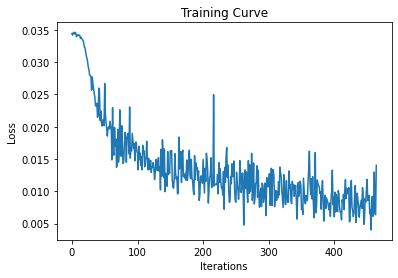

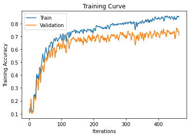

```
Final Training Accuracy: 0.8518518518518519
Final Validation Accuracy: 0.7078189300411523
Total time elapsed: 3027.77 seconds
```

```python
use_cuda = True

m1 = ASLClassifier1()

if use_cuda and torch.cuda.is_available():
  m1.cuda()
  print('CUDA is available!  Training on GPU ...')
else:
  print('CUDA is not available.  Training on CPU ...')

master_path = "/content/drive/My Drive/MASc First Year/MIE1517/Lab2/Lab_3b_Gesture_Dataset"
train(m1, data_path=master_path, batch_size=64, learning_rate=0.001, num_epochs=15)
```

### Part (c) “Overfit” to a Small Dataset - 3 pt

One way to sanity check our neural network model and training code is to check whether the model is capable of “overfitting” or “memorizing” a small dataset. A properly constructed CNN with correct training code should be able to memorize the answers to a small number of images quickly.

Construct a small dataset (e.g. just the images that you have collected). Then show that your model and training code is capable of memorizing the labels of this small data set.

With a large batch size (e.g. the entire small dataset) and learning rate that is not too high, You should be able to obtain a 100% training accuracy on that small dataset relatively quickly (within 200 iterations).

```
CUDA is available!  Training on GPU ...
```

```
Epoch 0: Train acc: 0.23809523809523808 |Validation acc: 0.0
Epoch 1: Train acc: 0.23809523809523808 |Validation acc: 0.0
Epoch 2: Train acc: 0.19047619047619047 |Validation acc: 0.0
Epoch 3: Train acc: 0.2857142857142857 |Validation acc: 0.0
Epoch 4: Train acc: 0.42857142857142855 |Validation acc: 0.0
Epoch 5: Train acc: 0.5238095238095238 |Validation acc: 0.0
Epoch 6: Train acc: 0.5238095238095238 |Validation acc: 0.0
Epoch 7: Train acc: 0.5238095238095238 |Validation acc: 0.0
Epoch 8: Train acc: 0.5238095238095238 |Validation acc: 0.0
Epoch 9: Train acc: 0.6190476190476191 |Validation acc: 0.0
Epoch 10: Train acc: 0.6190476190476191 |Validation acc: 0.0
Epoch 11: Train acc: 0.7619047619047619 |Validation acc: 0.0
Epoch 12: Train acc: 0.6666666666666666 |Validation acc: 0.0
Epoch 13: Train acc: 0.7619047619047619 |Validation acc: 0.0
Epoch 14: Train acc: 0.8095238095238095 |Validation acc: 0.0
Epoch 15: Train acc: 0.8571428571428571 |Validation acc: 0.0
Epoch 16: Train acc: 0.8571428571428571 |Validation acc: 0.0
Epoch 17: Train acc: 0.8571428571428571 |Validation acc: 0.0
Epoch 18: Train acc: 0.9047619047619048 |Validation acc: 0.0
Epoch 19: Train acc: 1.0 |Validation acc: 0.0
Epoch 20: Train acc: 1.0 |Validation acc: 0.0
Epoch 21: Train acc: 1.0 |Validation acc: 0.0
Epoch 22: Train acc: 1.0 |Validation acc: 0.0
Epoch 23: Train acc: 1.0 |Validation acc: 0.0
Epoch 24: Train acc: 1.0 |Validation acc: 0.0
Epoch 25: Train acc: 1.0 |Validation acc: 0.0
Epoch 26: Train acc: 1.0 |Validation acc: 0.0
Epoch 27: Train acc: 1.0 |Validation acc: 0.0
Epoch 28: Train acc: 1.0 |Validation acc: 0.0
Epoch 29: Train acc: 1.0 |Validation acc: 0.0
Epoch 30: Train acc: 1.0 |Validation acc: 0.0
Epoch 31: Train acc: 1.0 |Validation acc: 0.0
Epoch 32: Train acc: 1.0 |Validation acc: 0.0
Epoch 33: Train acc: 1.0 |Validation acc: 0.0
Epoch 34: Train acc: 1.0 |Validation acc: 0.0
Epoch 35: Train acc: 1.0 |Validation acc: 0.0
Epoch 36: Train acc: 1.0 |Validation acc: 0.0
Epoch 37: Train acc: 1.0 |Validation acc: 0.3333333333333333
Epoch 38: Train acc: 1.0 |Validation acc: 0.3333333333333333
Epoch 39: Train acc: 1.0 |Validation acc: 0.3333333333333333
Epoch 40: Train acc: 1.0 |Validation acc: 0.3333333333333333
Epoch 41: Train acc: 1.0 |Validation acc: 0.3333333333333333
Epoch 42: Train acc: 1.0 |Validation acc: 0.3333333333333333
Epoch 43: Train acc: 1.0 |Validation acc: 0.3333333333333333
Epoch 44: Train acc: 1.0 |Validation acc: 0.3333333333333333
Epoch 45: Train acc: 1.0 |Validation acc: 0.3333333333333333
Epoch 46: Train acc: 1.0 |Validation acc: 0.3333333333333333
Epoch 47: Train acc: 1.0 |Validation acc: 0.3333333333333333
Epoch 48: Train acc: 1.0 |Validation acc: 0.3333333333333333
Epoch 49: Train acc: 1.0 |Validation acc: 0.3333333333333333
```

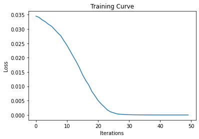

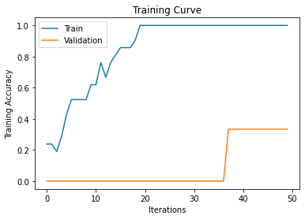

```
Final Training Accuracy: 1.0
Final Validation Accuracy: 0.3333333333333333
Total time elapsed: 28.90 seconds
```

```python
use_cuda = True

m1 = ASLClassifier1()

if use_cuda and torch.cuda.is_available():
  m1.cuda()
  print('CUDA is available!  Training on GPU ...')
else:
  print('CUDA is not available.  Training on CPU ...')

# Since there are only 27 images, almost all the images will be split into the training set.
smalldata_path = "/content/drive/My Drive/MASc First Year/MIE1517/Lab2/hu_1002224728"
train(m1, data_path=smalldata_path, batch_size=64, learning_rate=0.001, num_epochs=50)

# After 18 epoch, the model reaches 100% accuracy on the training set.
```

### Part 3. Hyperparameter Search [8 pt]

### Part (a) - 2 pt

List 3 hyperparameters that you think are most worth tuning. Choose at least one hyperparameter related to the model architecture.

```python
# batch_size, learning rate and number of con/pooling layers
# I have no more than 2000 training data, setting larger batch size requires
# higher learning rate, which will never converge. Need to find an ideal batch
# size works for smaller training set.

# Since our batch size is the key, learning rate highly depends on the batch
# size. Larger learning rate will make the training detrimental. Learning rate
# determines how fast the model can reach the optimal solutions, but cannot suffer
# the problem of not unable to find the minimal points.

# Number of parameters are the key to prevent overfitting. Since our dataset is
# not big, the model should not have too many parameters. Hence, adding more
# conv layer and max pooling layers can reduce the number of parameters.
```

### Part (b) - 2 pt

Tune the hyperparameters you listed in Part (a), trying as many values as you need to until you feel satisfied that you are getting a good model. Plot the training curve of at least 4 different hyperparameter settings.

```
CUDA is available!  Training on GPU ...
```

```
Epoch 0: Train acc: 0.10802469135802469 |Validation acc: 0.1440329218106996
Epoch 1: Train acc: 0.11522633744855967 |Validation acc: 0.102880658436214
Epoch 2: Train acc: 0.12551440329218108 |Validation acc: 0.13168724279835392
Epoch 3: Train acc: 0.12757201646090535 |Validation acc: 0.12757201646090535
Epoch 4: Train acc: 0.44393004115226337 |Validation acc: 0.42386831275720166
Epoch 5: Train acc: 0.6635802469135802 |Validation acc: 0.6172839506172839
Epoch 6: Train acc: 0.7150205761316872 |Validation acc: 0.6419753086419753
Epoch 7: Train acc: 0.7371399176954733 |Validation acc: 0.6213991769547325
Epoch 8: Train acc: 0.7808641975308642 |Validation acc: 0.6954732510288066
Epoch 9: Train acc: 0.8070987654320988 |Validation acc: 0.7037037037037037
Epoch 10: Train acc: 0.8034979423868313 |Validation acc: 0.7160493827160493
Epoch 11: Train acc: 0.8338477366255144 |Validation acc: 0.7325102880658436
Epoch 12: Train acc: 0.8801440329218106 |Validation acc: 0.7078189300411523
Epoch 13: Train acc: 0.8960905349794238 |Validation acc: 0.6790123456790124
Epoch 14: Train acc: 0.8816872427983539 |Validation acc: 0.691358024691358
```

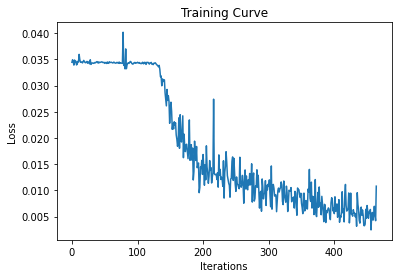

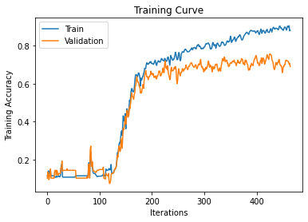

```
Final Training Accuracy: 0.8816872427983539
Final Validation Accuracy: 0.691358024691358
Total time elapsed: 4176.25 seconds
```

```python
# Model 1, batch size = 64, learning rate = 0.0025, epoch = 15
# faster learning rate, suffers problem that cannot find a minima at the beginning.
# Final Training Accuracy: 0.8816872427983539
# Final Validation Accuracy: 0.691358024691358
use_cuda = True

m1_bs64_lr00025_e15 = ASLClassifier1()

if use_cuda and torch.cuda.is_available():
  m1_bs64_lr00025_e15.cuda()
  print('CUDA is available!  Training on GPU ...')
else:
  print('CUDA is not available.  Training on CPU ...')

master_path = "/content/drive/My Drive/MASc First Year/MIE1517/Lab2/Lab_3b_Gesture_Dataset"
train(m1_bs64_lr00025_e15, data_path=master_path, batch_size=64, learning_rate=0.0025, num_epochs=15)
```

```
CUDA is available!  Training on GPU ...
Epoch 0: Train acc: 0.11728395061728394 |Validation acc: 0.102880658436214
Epoch 1: Train acc: 0.1383744855967078 |Validation acc: 0.09465020576131687
Epoch 2: Train acc: 0.2875514403292181 |Validation acc: 0.24279835390946503
Epoch 3: Train acc: 0.3343621399176955 |Validation acc: 0.30864197530864196
Epoch 4: Train acc: 0.46296296296296297 |Validation acc: 0.41975308641975306
Epoch 5: Train acc: 0.5380658436213992 |Validation acc: 0.4732510288065844
Epoch 6: Train acc: 0.6275720164609053 |Validation acc: 0.5349794238683128
Epoch 7: Train acc: 0.6574074074074074 |Validation acc: 0.5596707818930041
Epoch 8: Train acc: 0.7047325102880658 |Validation acc: 0.5308641975308642
Epoch 9: Train acc: 0.7170781893004116 |Validation acc: 0.5720164609053497
Epoch 10: Train acc: 0.779835390946502 |Validation acc: 0.6049382716049383
Epoch 11: Train acc: 0.816358024691358 |Validation acc: 0.6255144032921811
Epoch 12: Train acc: 0.8431069958847737 |Validation acc: 0.6337448559670782
Epoch 13: Train acc: 0.8626543209876543 |Validation acc: 0.6255144032921811
Epoch 14: Train acc: 0.8842592592592593 |Validation acc: 0.6337448559670782
```

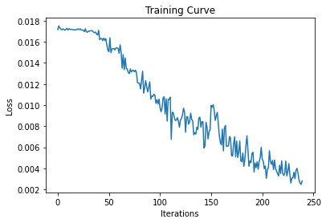

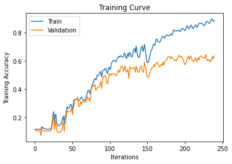

```
Final Training Accuracy: 0.8842592592592593
Final Validation Accuracy: 0.6337448559670782
Total time elapsed: 2014.48 seconds
```

```python
# Model 1, batch size = 128, learning rate = 0.0025, epoch = 15
# Final Training Accuracy: 0.8842592592592593
# Final Validation Accuracy: 0.6337448559670782
# Need faster learning rate, but start to overfit at 100th iterations.
use_cuda = True

m1_bs128_lr00025_e15 = ASLClassifier1()

if use_cuda and torch.cuda.is_available():
  m1_bs128_lr00025_e15.cuda()
  print('CUDA is available!  Training on GPU ...')
else:
  print('CUDA is not available.  Training on CPU ...')

master_path = "/content/drive/My Drive/MASc First Year/MIE1517/Lab2/Lab_3b_Gesture_Dataset"
train(m1_bs128_lr00025_e15, data_path=master_path, batch_size=128, learning_rate=0.0025, num_epochs=15)
```

```python
# Model 2
# From the three trained m1 results, they all have some problems of overfitting.
# To reduce overfitting, one way is to reduce number of parameters. Adding one
# more conv layer and max pooling layer will make the model deeper, more powerful
# but has less number of parameters (reduce hidden units) at the same time.
# First model as around 450 thousands paramaters, now model 2 only has around
# 95 thousands paramaters.

class ASLClassifier2(nn.Module):
    def __init__(self):
        super(ASLClassifier2, self).__init__()
        self.name = 'ASLClassifier2'
        self.conv1 = nn.Conv2d(3, 5, 5) #in_channels, out_chanels, kernel_size
        self.pool = nn.MaxPool2d(2, 2) #kernel_size, stride
        self.conv2 = nn.Conv2d(5, 5, 5)
        self.conv3 = nn.Conv2d(5, 5, 5)
        self.fc1 = nn.Linear(24*24*5, 32)
        self.fc2 = nn.Linear(32, 9)

    def forward(self, x):
        x = self.pool(F.relu(self.conv1(x)))
        x = self.pool(F.relu(self.conv2(x)))
        x = self.pool(F.relu(self.conv3(x)))
        x = x.view(-1, 24*24*5)
        x = F.relu(self.fc1(x))
        x = self.fc2(x)
        return x
# 94129
```

```python
# keep
m2 = ASLClassifier2()
for param in m2.parameters():
    print(param.shape)
print(sum(p.numel() for p in m2.parameters()))
```

```
torch.Size([5, 3, 5, 5])
torch.Size([5])
torch.Size([5, 5, 5, 5])
torch.Size([5])
torch.Size([5, 5, 5, 5])
torch.Size([5])
torch.Size([32, 2880])
torch.Size([32])
torch.Size([9, 32])
torch.Size([9])
94129
```

```
CUDA is available!  Training on GPU ...
Epoch 0: Train acc: 0.4254115226337449 |Validation acc: 0.3868312757201646
Epoch 1: Train acc: 0.6625514403292181 |Validation acc: 0.5967078189300411
Epoch 2: Train acc: 0.7026748971193416 |Validation acc: 0.588477366255144
Epoch 3: Train acc: 0.727366255144033 |Validation acc: 0.6625514403292181
Epoch 4: Train acc: 0.7536008230452675 |Validation acc: 0.6872427983539094
Epoch 5: Train acc: 0.772119341563786 |Validation acc: 0.6872427983539094
Epoch 6: Train acc: 0.7649176954732511 |Validation acc: 0.691358024691358
Epoch 7: Train acc: 0.7962962962962963 |Validation acc: 0.720164609053498
Epoch 8: Train acc: 0.8256172839506173 |Validation acc: 0.720164609053498
Epoch 9: Train acc: 0.8353909465020576 |Validation acc: 0.7530864197530864
Epoch 10: Train acc: 0.8415637860082305 |Validation acc: 0.7325102880658436
Epoch 11: Train acc: 0.8611111111111112 |Validation acc: 0.7325102880658436
Epoch 12: Train acc: 0.8909465020576132 |Validation acc: 0.7242798353909465
Epoch 13: Train acc: 0.9063786008230452 |Validation acc: 0.7489711934156379
Epoch 14: Train acc: 0.9063786008230452 |Validation acc: 0.7448559670781894
```

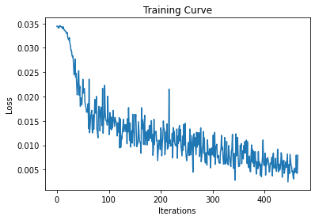

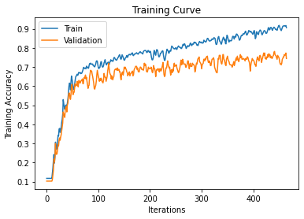

```
Final Training Accuracy: 0.9063786008230452
Final Validation Accuracy: 0.7448559670781894
Total time elapsed: 3916.24 seconds
```

```python
# Model 2, batch size = 64, learning rate = 0.001, epoch = 15
# Final Training Accuracy: 0.9063786008230452
# Final Validation Accuracy: 0.7448559670781894
# By having less number of parameters and deep, the model converges faster with
# higher accuracy. However, the learning time took very long, need to speed up
# the learning rate.
use_cuda = True

m2_bs64_lr0001_e15 = ASLClassifier2()

if use_cuda and torch.cuda.is_available():
  m2_bs64_lr0001_e15.cuda()
  print('CUDA is available!  Training on GPU ...')
else:
  print('CUDA is not available.  Training on CPU ...')

master_path = "/content/drive/My Drive/MASc First Year/MIE1517/Lab2/Lab_3b_Gesture_Dataset"
train(m2_bs64_lr0001_e15, data_path=master_path, batch_size=64, learning_rate=0.001, num_epochs=15)
```

```
CUDA is available!  Training on GPU ...
```

```
Epoch 0: Train acc: 0.4038065843621399 |Validation acc: 0.3786008230452675
Epoch 1: Train acc: 0.6640946502057613 |Validation acc: 0.6296296296296297
Epoch 2: Train acc: 0.6790123456790124 |Validation acc: 0.6460905349794238
Epoch 3: Train acc: 0.7561728395061729 |Validation acc: 0.6666666666666666
Epoch 4: Train acc: 0.7803497942386831 |Validation acc: 0.7160493827160493
Epoch 5: Train acc: 0.808641975308642 |Validation acc: 0.7078189300411523
Epoch 6: Train acc: 0.8287037037037037 |Validation acc: 0.7489711934156379
Epoch 7: Train acc: 0.8297325102880658 |Validation acc: 0.7613168724279835
Epoch 8: Train acc: 0.8693415637860082 |Validation acc: 0.7777777777777778
Epoch 9: Train acc: 0.88940329218107 |Validation acc: 0.7942386831275721
Epoch 10: Train acc: 0.8950617283950617 |Validation acc: 0.7736625514403292
Epoch 11: Train acc: 0.9151234567901234 |Validation acc: 0.7942386831275721
Epoch 12: Train acc: 0.9233539094650206 |Validation acc: 0.7613168724279835
Epoch 13: Train acc: 0.9053497942386831 |Validation acc: 0.7407407407407407
Epoch 14: Train acc: 0.8996913580246914 |Validation acc: 0.7613168724279835
```

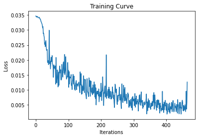

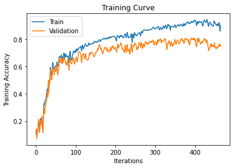

```
Final Training Accuracy: 0.8996913580246914
Final Validation Accuracy: 0.7613168724279835
Total time elapsed: 3249.20 seconds
```

```python
# Best Model - Model 2, batch size = 64, learning rate = 0.0025, epoch = 15
# Final Training Accuracy: 0.8996913580246914
# Final Validation Accuracy: 0.7613168724279835
use_cuda = True

m2_bs64_lr00025_e15 = ASLClassifier2()

if use_cuda and torch.cuda.is_available():
  m2_bs64_lr00025_e15.cuda()
  print('CUDA is available!  Training on GPU ...')
else:
  print('CUDA is not available.  Training on CPU ...')

master_path = "/content/drive/My Drive/MASc First Year/MIE1517/Lab2/Lab_3b_Gesture_Dataset"
train(m2_bs64_lr00025_e15, data_path=master_path, batch_size=64, learning_rate=0.0025, num_epochs=15)
```

### Part (c) - 2 pt

Choose the best model out of all the ones that you have trained. Justify your choice.

```python
# The best model is my second model with less parameters, batch size = 64,
# learning rate = 0.0025, epoch = 15.

# After trying different batch size, 64 seems to be the most ideal batch size
# for our dataset. Since the training set only has around 1900 data, making the
# batch size larger require higher learning rate, which has difficulty in
# convergence. Since the batch size is small, I should find a relatively lower
# learning rate. But learning rate that is slow will cause the learning process
# being slow and take longer time to train. So the most ideal learning rate
# is 0.0025.

# Having too many parameters requires a larger set of training data, but we do not
# have more than 2000 data, so we have to reduce the number of parameters by adding
# two more layers to feed the smaller number of training samples. Model 2 has less
# severe problem of overfitting since the gap between training and validation set
# accuracies become smaller for model 2. The validation accuracy near the end can
# also reach 0.79.
```

### Part (d) - 2 pt

Report the test accuracy of your best model. You should only do this step once and prior to this step you should have only used the training and validation data.

```python
master_path = "/content/drive/My Drive/MASc First Year/MIE1517/Lab2/Lab_3b_Gesture_Dataset"
train_loader, val_loader, test_loader = get_data_loader(data_path=master_path, batch_size = 64)

print("Test accuracy: {}".format(get_accuracy(m2_bs64_lr00025_e15, test_loader)))
```

```
Test accuracy: 0.8073770491803278
```

### Part 4. Transfer Learning [12 pt]

For many image classification tasks, it is generally not a good idea to train a very large deep neural network model from scratch due to the enormous compute requirements and lack of sufficient amounts of training data.

One of the better options is to try using an existing model that performs a similar task to the one you need to solve. This method of utilizing a pre-trained network for other similar tasks is broadly termed **Transfer Learning**. In this assignment, we will use Transfer Learning to extract features from the hand gesture images. Then, train a smaller network to use these features as input and classify the hand gestures.

As you have learned from the CNN lecture, convolution layers extract various features from the images which get utilized by the fully connected layers for correct classification. AlexNet architecture played a pivotal role in establishing Deep Neural Nets as a go-to tool for image classification problems and we will use an ImageNet pre-trained AlexNet model to extract features in this assignment.

### Part (a) - 3 pt

Here is the code to load the AlexNet network, with pretrained weights. When you first run the code, PyTorch will download the pretrained weights from the internet.

```python
import torchvision.models
alexnet = torchvision.models.alexnet(pretrained=True)
```

```
Downloading: "https://download.pytorch.org/models/alexnet-owt-7be5be79.pth" to /root/.cache/torch/hub/checkpoints/alexnet-owt-7be5be79.pth
```

The alexnet model is split up into two components: *alexnet.features* and *alexnet.classifier*. The first neural network component, *alexnet.features*, is used to compute convolutional features, which are taken as input in *alexnet.classifier*.

The neural network alexnet.features expects an image tensor of shape Nx3x224x224 as input and it will output a tensor of shape Nx256x6x6 . (N = batch size).

Compute the AlexNet features for each of your training, validation, and test data. Here is an example code snippet showing how you can compute the AlexNet features for some images (your actual code might be different):

```python
# img = ... a PyTorch tensor with shape [N,3,224,224] containing hand images ...
# features = alexnet.features(img)
```

**Save the computed features**. You will be using these features as input to your neural network in Part (b), and you do not want to re-compute the features every time. Instead, run *alexnet.features* once for each image, and save the result.

```python
import os
torch.manual_seed(100)
np.random.seed(100)

transform = transforms.Compose(
    [transforms.Resize([224, 224]),
     transforms.ToTensor()])

# load all the images into one loader.
dataset = torchvision.datasets.ImageFolder(root = '/content/drive/My Drive/MASc First Year/MIE1517/Lab2/Lab_3b_Gesture_Dataset', transform=transform)
alldata_loader = torch.utils.data.DataLoader(dataset, batch_size=1,num_workers=1)

# Make alexnet features on every image from the loader, and save the features
# like the format from the original dataset. Each feature goes into the corresponding label folder.
target_classes = ('A', 'B', 'C', 'D', 'E', 'F', 'G', 'H', 'I')
master_path = '/content/drive/My Drive/MASc First Year/MIE1517/Lab2'
n = 0
for img, label in alldata_loader:
    features = alexnet.features(img)
    features_tensor = torch.from_numpy(features.detach().numpy())

    folder_name = master_path + '/Features/' + str(target_classes[label])
    if not os.path.isdir(folder_name):
        os.mkdir(folder_name)
    features_tensor_s = torch.squeeze(features_tensor, 0)
    torch.save(features_tensor_s, folder_name + '/' + str(n) + '.tensor')
    n += 1
```

### Part (b) - 3 pt

Build a convolutional neural network model that takes as input these AlexNet features, and makes a prediction. Your model should be a subclass of nn.Module.

Explain your choice of neural network architecture: how many layers did you choose? What types of layers did you use: fully-connected or convolutional? What about other decisions like pooling layers, activation functions, number of channels / hidden units in each layer?

Here is an example of how your model may be called:

```python
# features = ... load precomputed alexnet.features(img) ...
# output = model(features)
# prob = F.softmax(output)
```

```python
# Since the input size is tranformed into 6x6 (small), the kernel size must be
# smaller, and no need to do a pooling layer to downsampling information from the
# conv layer. I applied two fully connected layers right after the conv layers to
# flatten and learn non-linear combinations of those high level features produced
# by conv layer. I made the output channels as 30 which is not too big and not
# too small. Since larger number of out_channles will can increase parameters
# cause overfitting with small training set, too few out_channels cannot capture
# all the important information, so I think 30 is a good fit. ReLu is on the conv
# layer to deal with non-linearity from the conv layers and prevent the
# exponential growth in the computation for CNN.

class AlexNetCNN(nn.Module):
    def __init__(self):
        super(AlexNetCNN, self).__init__()
        self.name = 'AlexNetCNN'
        self.conv1 = nn.Conv2d(256, 30, 3) #in_channels, out_chanels, kernel_size
        self.fc1 = nn.Linear(30*4*4, 32)
        self.fc2 = nn.Linear(32, 9)

    def forward(self, x):
        x = F.relu(self.conv1(x))
        x = x.view(-1, 30*4*4)
        x = F.relu(self.fc1(x))
        x = self.fc2(x)
        return x
```

### Part (c) - 3 pt

Train your new network, including any hyperparameter tuning. Plot and submit the training curve of your best model only.

Note: Depending on how you are caching (saving) your AlexNet features, PyTorch might still be tracking updates to the **AlexNet weights**, which we are not tuning. One workaround is to convert your AlexNet feature tensor into a numpy array, and then back into a PyTorch tensor.

```python
# tensor = torch.from_numpy(tensor.detach().numpy())
```

```python
# Load all features from the freatures folder
all_features = torchvision.datasets.DatasetFolder('/content/drive/My Drive/MASc First Year/MIE1517/Lab2/Features', loader=torch.load, extensions=('.tensor'))

# Similar strategy as get_data_loader function to split those features using
# their indices into 80% training, 10% validation and 10% test set.
indices = np.arange(len(all_features))
np.random.shuffle(indices)
split1 = int(len(indices) * 0.8) # training set split at 80%
split2 = int(len(indices) * 0.9) # validation set split at 90%

# Using batch_size 64 to load everything into training, val, and test features loader.
bs = 64
train_f_sampler = SubsetRandomSampler(indices[:split1])
train_f_loader = torch.utils.data.DataLoader(all_features, batch_size=bs,
                                               num_workers=1, sampler=train_f_sampler)

val_f_sampler = SubsetRandomSampler(indices[split1:split2])
val_f_loader = torch.utils.data.DataLoader(all_features, batch_size=bs,
                                              num_workers=1, sampler=val_f_sampler)

test_f_sampler = SubsetRandomSampler(indices[split2:])
test_f_loader = torch.utils.data.DataLoader(all_features, batch_size=bs,
                                             num_workers=1, sampler=test_f_sampler)
```

```
CUDA is available!  Training on GPU ...
Epoch 0: Train acc: 0.7057613168724279 |Validation acc: 0.6995884773662552
Epoch 1: Train acc: 0.8225308641975309 |Validation acc: 0.8024691358024691
Epoch 2: Train acc: 0.8935185185185185 |Validation acc: 0.8600823045267489
Epoch 3: Train acc: 0.9171810699588477 |Validation acc: 0.8724279835390947
Epoch 4: Train acc: 0.9377572016460906 |Validation acc: 0.9012345679012346
Epoch 5: Train acc: 0.9629629629629629 |Validation acc: 0.9094650205761317
Epoch 6: Train acc: 0.9655349794238683 |Validation acc: 0.9053497942386831
Epoch 7: Train acc: 0.9382716049382716 |Validation acc: 0.8806584362139918
Epoch 8: Train acc: 0.9650205761316872 |Validation acc: 0.9012345679012346
Epoch 9: Train acc: 0.9789094650205762 |Validation acc: 0.9053497942386831
Epoch 10: Train acc: 0.9840534979423868 |Validation acc: 0.9300411522633745
Epoch 11: Train acc: 0.9881687242798354 |Validation acc: 0.9135802469135802
Epoch 12: Train acc: 0.9902263374485597 |Validation acc: 0.9300411522633745
Epoch 13: Train acc: 0.9943415637860082 |Validation acc: 0.9176954732510288
Epoch 14: Train acc: 0.9979423868312757 |Validation acc: 0.9300411522633745
```

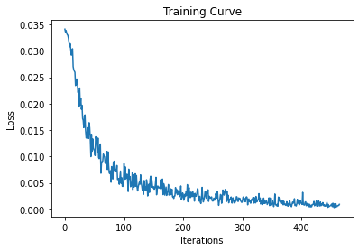

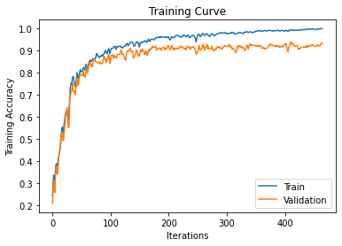

```
Final Training Accuracy: 0.9979423868312757
Final Validation Accuracy: 0.9300411522633745
Total time elapsed: 1513.97 seconds
```

```python
# AlexNet CNN - batch size = 64, learning rate = 0.0005, epoch = 15
# Final Training Accuracy: 0.9979423868312757
# Final Validation Accuracy: 0.9300411522633745
# Very good performance, no severe overfitting problem.

use_cuda = True
tl_model = AlexNetCNN()
if use_cuda and torch.cuda.is_available():
  tl_model.cuda()
  print('CUDA is available!  Training on GPU ...')
else:
  print('CUDA is not available.  Training on CPU ...')
train(tl_model, train_loader = train_f_loader, val_loader = val_f_loader,
      batch_size = bs, learning_rate=0.0005, num_epochs=15)
```

### Part (d) - 3 pt

Report the test accuracy of your best model. How does the test accuracy compare to Part 3(d) without transfer learning?

```python
if use_cuda and torch.cuda.is_available():
    tl_model = tl_model.cuda()

print("Test accuracy: {}".format(get_accuracy(tl_model, test_f_loader)))
# Apply alexnet features to our original dataset, make the training process
# faster (1513.97 seconds) with a much simpler CNN and more accurate to reach
# final accuracy as 0.94. The best model from previous part can reach 0.81, the
# trainig time is 3249 seconds.
```

```
Test accuracy: 0.9426229508196722
```

### Part 5. Testing on New Data [5 pt]

As a final step in testing we will be revisiting the sample images that you had collected and submitted at the start of this lab. These sample images should be untouched and will be used to demonstrate how well your model works at identifying your hand guestures.

Using the best transfer learning model developed in Part 4. Report the test accuracy on your sample images and how it compares to the test accuracy obtained in Part 4(d)? How well did your model do for the different hand guestures? Provide an explanation for why you think your model performed the way it did?

This question will also be evaluated on the overal performance achieved.

```python
import os
torch.manual_seed(100)
np.random.seed(100)

transform = transforms.Compose(
    [transforms.Resize([224, 224]),
     transforms.ToTensor()])

# Load all my data with some transformations
dataset = torchvision.datasets.ImageFolder(root = '/content/drive/My Drive/MASc First Year/MIE1517/Lab2/hu_1002224728', transform=transform)
alldata_loader = torch.utils.data.DataLoader(dataset, batch_size=1,num_workers=1)

# Apply alexnet features to my data and save them into a folder. All features
# are saved to the corresponding label folder.
target_classes = ('A', 'B', 'C', 'D', 'E', 'F', 'G', 'H', 'I')
master_path = '/content/drive/My Drive/MASc First Year/MIE1517/Lab2'
n = 0
for img, label in alldata_loader:
    features = alexnet.features(img)
    features_tensor = torch.from_numpy(features.detach().numpy())

    folder_name = master_path + '/SmallSet_Features/' + str(target_classes[label])
    if not os.path.isdir(folder_name):
        os.mkdir(folder_name)
    features_tensor_s = torch.squeeze(features_tensor, 0)
    torch.save(features_tensor_s, folder_name + '/' + str(n) + '.tensor')
    n += 1
```

```python
# Load features
ss_features = torchvision.datasets.DatasetFolder('/content/drive/My Drive/MASc First Year/MIE1517/Lab2/SmallSet_Features', loader=torch.load, extensions=('.tensor'))

# Put everything into one loader as the test set.
bs = 16
ss_f_loader = torch.utils.data.DataLoader(ss_features, batch_size=bs,
                                               num_workers=1)

if use_cuda and torch.cuda.is_available():
  tl_model = tl_model.cuda()

print("Test accuracy: {}".format(get_accuracy(tl_model, ss_f_loader)))
```

```
Test accuracy: 1.0
```

```python
# The test accuracy reaches 100% which is higher than Part 4d which is 94%.
# Because I only made 27 images, which is a much smaller dataset. Alexnet features
# which is build upon a huge set of data and our original dataset consists of
# near 2000 samples. By combining alexnet features with our dataset, the model
# should already capture and learn the key information/pattern to differentiate
# the hand gestures. In my photos, I try to make every gesture quite clear to
# distinguish, which might be easier to differentiate and result in 100% accuracy.
# However, alexnet features are very powerful by transfer the learning to make
# the training process more efficient and the result much more accurate and efficient.
```

### Saving to HTML

Detailed instructions for saving to HTML can be found [here](https://stackoverflow.com/questions/53460051/convert-ipynb-notebook-to-html-in-google-colab/64487858#64487858). Provided below are a summary of the instructions:

(1) download your ipynb file by clicking on File->Download.ipynb

(2) reupload your file to the temporary Google Colab storage (you can access the temporary storage from the tab to the left)

(3) run the following:

```python
%%shell
jupyter nbconvert --to html LAB_2_Hand_Gesture_Recognition.ipynb
```

(4) the html file will be available for download in the temporary Google Colab storage

(5) review the html file and make sure all the results are visible before submitting your assignment to Quercus